# Lab8

Sri Seshadri

3/10/2018

# 9.6.1 Support vector Classifier page 359

The svm() uses a different formulation other than the equations in 9.14 and 9.15, when kernel argument is set to linear. The svm() function uses a cost argument. When the cost is high the margin is narrow and very few points would be in the margin or violate the margin. When the cost is low, the margin is wider and there would be more points in the margin or violate the margin.

## Data generation

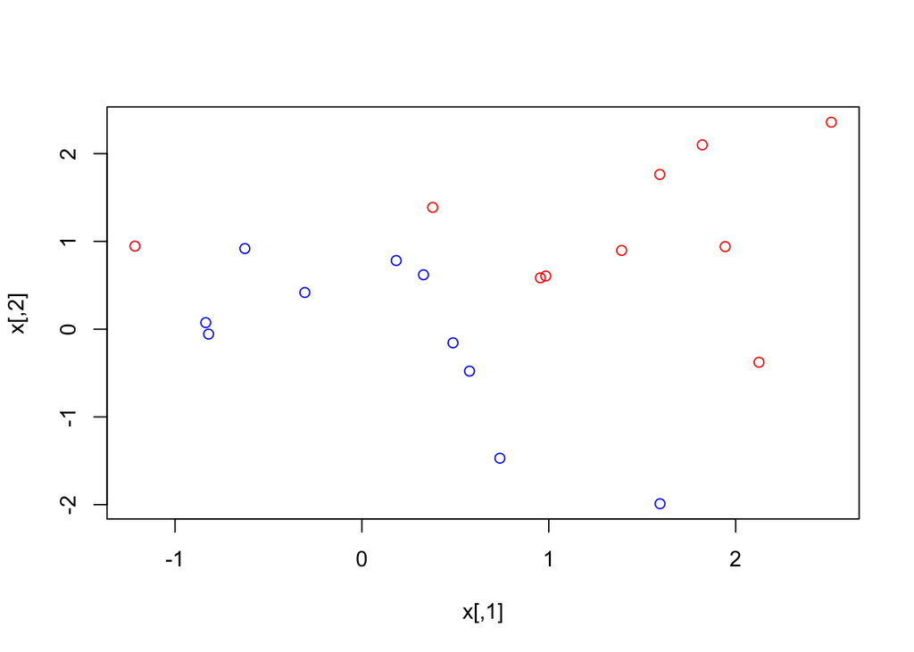

```r
set.seed(1)
x = matrix(rnorm(20*2), ncol = 2)
y = c(rep(-1,10),rep(1,10))
x[y==1,] = x[y==1,] + 1

plot(x,col=(3-y))
```

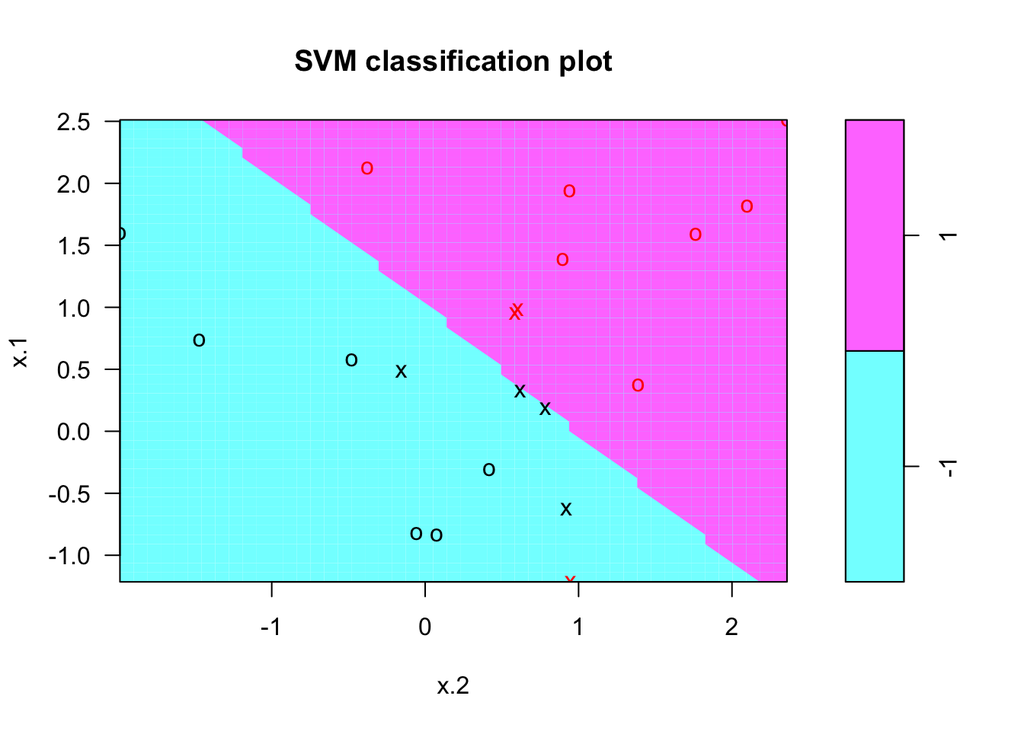

```r
dat = data.frame(x = x, y = as.factor(y))
library(e1071)
# scale is set to F, there are cases where we want the scale to be T
svmfit = svm(y~., data = dat, kernel = "linear", cost = 10, scale = F)
plot(svmfit,dat)
```

```r
summary(svmfit)
```

```
##
## Call:
## svm(formula = y ~ ., data = dat, kernel = "linear", cost = 10,
##     scale = F)
##
##
## Parameters:
##    SVM-Type:  C-classification
##  SVM-Kernel:  linear
##        cost:  10
##       gamma:  0.5
##
## Number of Support Vectors:  7
##
##  ( 4 3 )
##
##
## Number of Classes:  2
##
## Levels:
##  -1 1
```

Here the support vectors are marked with asterix. There are 7 support vectors. They can be queried as follows

```r
svmfit$index
```

```
## [1]  1  2  5  7 14 16 17
```

What if we used a smaller value for the cost ?

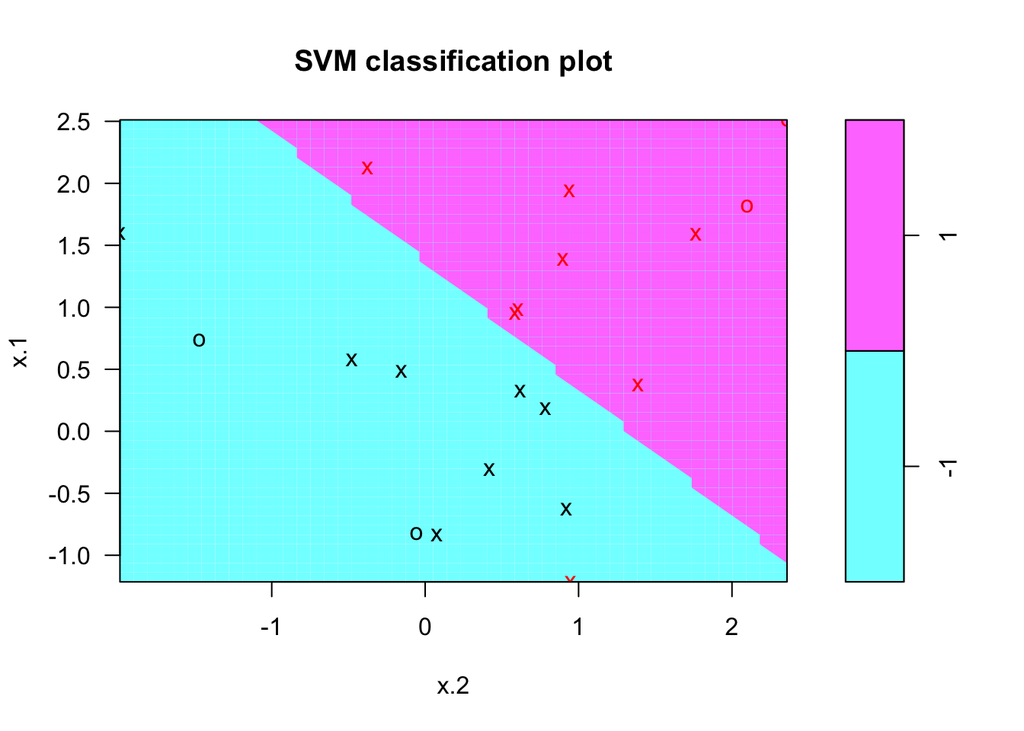

```r
svmfit.lowcost = svm(y ~ ., data = dat, cost = 0.1, kernel = "linear")
plot(svmfit.lowcost,dat)
```

```r
svmfit.lowcost$index
```

```
##  [1]  1  2  3  4  5  7  9 10 12 13 14 15 16 17 18 20
```

```r
summary(svmfit.lowcost)
```

```
##
## Call:
## svm(formula = y ~ ., data = dat, cost = 0.1, kernel = "linear")
##
##
## Parameters:
##    SVM-Type:  C-classification
##  SVM-Kernel:  linear
##        cost:  0.1
##       gamma:  0.5
##
## Number of Support Vectors:  16
##
##  ( 8 8 )
##
##
## Number of Classes:  2
##
## Levels:
##  -1 1
```

## Page 361

The svm() foes not output the function of the hyperplane nor does it report the width of the margin. The tune() in e1071 performs a 10 fold cross validation on a set of model under consideration.

```r
set.seed(1)
tune.out = tune(svm,y~., data = dat,kernel = "linear", ranges = list(cost = c(0.001,0.01,0.1,1,5,10,100)))
summary(tune.out)
```

```
##
## Parameter tuning of 'svm':
##
## - sampling method: 10-fold cross validation
##
## - best parameters:
##  cost
##   0.1
##
## - best performance: 0.1
##
## - Detailed performance results:
##    cost error dispersion
## 1 1e-03  0.70  0.4216370
## 2 1e-02  0.70  0.4216370
## 3 1e-01  0.10  0.2108185
## 4 1e+00  0.15  0.2415229
## 5 5e+00  0.15  0.2415229
## 6 1e+01  0.15  0.2415229
## 7 1e+02  0.15  0.2415229
```

The best model is when cost is 0.1. The best model can be retrieved by …

```r
tune.out$best.model
```

```
##
## Call:
## best.tune(method = svm, train.x = y ~ ., data = dat, ranges = list(cost = c(0.001,
##     0.01, 0.1, 1, 5, 10, 100)), kernel = "linear")
##
##
## Parameters:
##    SVM-Type:  C-classification
##  SVM-Kernel:  linear
##        cost:  0.1
##       gamma:  0.5
##
## Number of Support Vectors:  16
```

```r
# tune.out$best.performance
# tune.out$best.parameters
```

## Using the best model to predict test cases… Here is how we retrive the best model.

```r
bestmod = tune.out$best.model
summary(bestmod)
```

```
##
## Call:
## best.tune(method = svm, train.x = y ~ ., data = dat, ranges = list(cost = c(0.001,
##     0.01, 0.1, 1, 5, 10, 100)), kernel = "linear")
##
##
## Parameters:
##    SVM-Type:  C-classification
##  SVM-Kernel:  linear
##        cost:  0.1
##       gamma:  0.5
##
## Number of Support Vectors:  16
##
##  ( 8 8 )
##
##
## Number of Classes:  2
##
## Levels:
##  -1 1
```

# Build test samples for testing best model from above. Page (361-362)

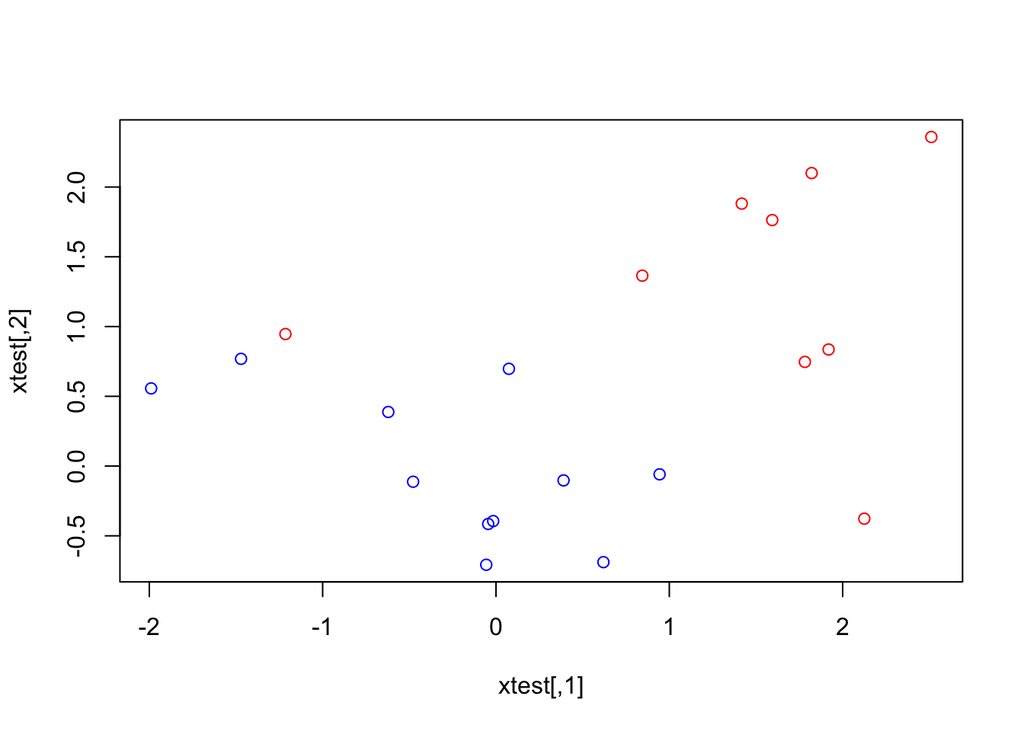

```r
#set.seed(1)
xtest = matrix(rnorm(20*2), ncol = 2)
ytest = sample(c(-1,1),20,rep = T)
xtest[ytest==1,] = xtest[ytest==1,] + 1
testdat = data.frame(x=xtest, y = as.factor(ytest))

plot(xtest,col = 3 - ytest)
```

## Prediciton using the best model from above

```r
ypred = predict(bestmod,testdat)
table(predict = ypred,truth = testdat$y)
```

```
##        truth
## predict -1  1
##      -1 11  1
##      1   0  8
```

```r
caret::confusionMatrix(ypred,testdat$y)
```

```
## Confusion Matrix and Statistics
##
##           Reference
## Prediction -1  1
##         -1 11  1
##         1   0  8
##
##                Accuracy : 0.95
##                  95% CI : (0.7513, 0.9987)
##     No Information Rate : 0.55
##     P-Value [Acc > NIR] : 0.0001114
##
##                   Kappa : 0.898
##  Mcnemar's Test P-Value : 1.0000000
##
##             Sensitivity : 1.0000
##             Specificity : 0.8889
##          Pos Pred Value : 0.9167
##          Neg Pred Value : 1.0000
##              Prevalence : 0.5500
##          Detection Rate : 0.5500
##    Detection Prevalence : 0.6000
##       Balanced Accuracy : 0.9444
##
##        'Positive' Class : -1
##
```

## trying a different cost metric

```r
svmfit.2 <- svm(y~. , data = dat, kernel = "linear", cost = .01, scale = F)
ypred.2 <- predict(svmfit.2, testdat)
caret::confusionMatrix(ypred.2,testdat$y)
```

```
## Confusion Matrix and Statistics
##
##           Reference
## Prediction -1  1
##         -1 11  2
##         1   0  7
##
##                Accuracy : 0.9
##                  95% CI : (0.683, 0.9877)
##     No Information Rate : 0.55
##     P-Value [Acc > NIR] : 0.0009274
##
##                   Kappa : 0.7938
##  Mcnemar's Test P-Value : 0.4795001
##
##             Sensitivity : 1.0000
##             Specificity : 0.7778
##          Pos Pred Value : 0.8462
##          Neg Pred Value : 1.0000
##              Prevalence : 0.5500
##          Detection Rate : 0.5500
##    Detection Prevalence : 0.6500
##       Balanced Accuracy : 0.8889
##
##        'Positive' Class : -1
##
```

# Quiz # 2

```r
svmfit.q2 <- svm(y~.,data = dat, kernel = "linear", cost = 1, scale = F)
ypred.q2 <- predict(svmfit.q2, testdat)
caret::confusionMatrix(ypred.q2,testdat$y)
```

```
## Confusion Matrix and Statistics
##
##           Reference
## Prediction -1  1
##         -1 11  1
##         1   0  8
##
##                Accuracy : 0.95
##                  95% CI : (0.7513, 0.9987)
##     No Information Rate : 0.55
##     P-Value [Acc > NIR] : 0.0001114
##
##                   Kappa : 0.898
##  Mcnemar's Test P-Value : 1.0000000
##
##             Sensitivity : 1.0000
##             Specificity : 0.8889
##          Pos Pred Value : 0.9167
##          Neg Pred Value : 1.0000
##              Prevalence : 0.5500
##          Detection Rate : 0.5500
##    Detection Prevalence : 0.6000
##       Balanced Accuracy : 0.9444
##
##        'Positive' Class : -1
##
```

# Situation where the samples are barely linearly separable

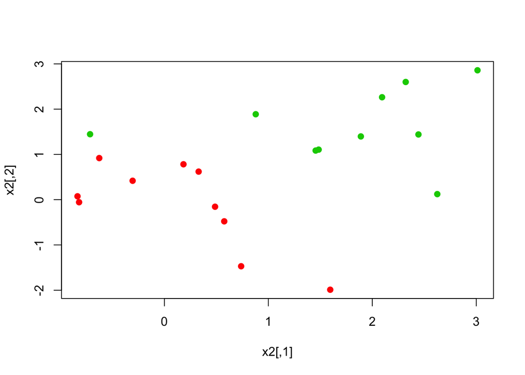

```r
x2 = x
y2 = y
x2[y2==1,] = x2[y2==1,] + 0.5
plot(x2,col=(y2+5)/2,pch = 19)
```

```r
dat2 = data.frame(x = x2, y=as.factor(y2))
```

```r
svmfit.3 <- svm(y~.,data = dat2, kernel = "linear", cost = 1e5)
summary(svmfit.3)
```

```
##
## Call:
## svm(formula = y ~ ., data = dat2, kernel = "linear", cost = 1e+05)
##
##
## Parameters:
##    SVM-Type:  C-classification
##  SVM-Kernel:  linear
##        cost:  1e+05
##       gamma:  0.5
##
## Number of Support Vectors:  3
##
##  ( 1 2 )
##
##
## Number of Classes:  2
##
## Levels:
##  -1 1
```

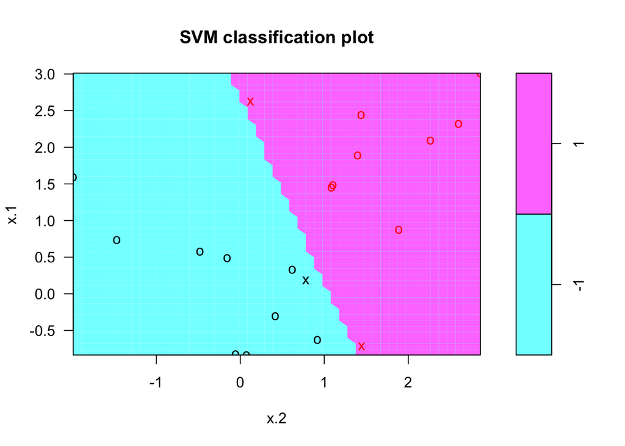

```r
plot(svmfit.3,dat2)
```

```r
caret::confusionMatrix(predict(svmfit.3,dat2),dat2$y)
```

```
## Confusion Matrix and Statistics
##
##           Reference
## Prediction -1  1
##         -1 10  0
##         1   0 10
##
##                Accuracy : 1
##                  95% CI : (0.8316, 1)
##     No Information Rate : 0.5
##     P-Value [Acc > NIR] : 9.537e-07
##
##                   Kappa : 1
##  Mcnemar's Test P-Value : NA
##
##             Sensitivity : 1.0
##             Specificity : 1.0
##          Pos Pred Value : 1.0
##          Neg Pred Value : 1.0
##              Prevalence : 0.5
##          Detection Rate : 0.5
##    Detection Prevalence : 0.5
##       Balanced Accuracy : 1.0
##
##        'Positive' Class : -1
##
```

Notice that there are few support vectors (x points). Its because the cost variable is high. I am curious how this model would perform on the test data… The guess is the data might have been over fit

# Generate test data for the above data set…

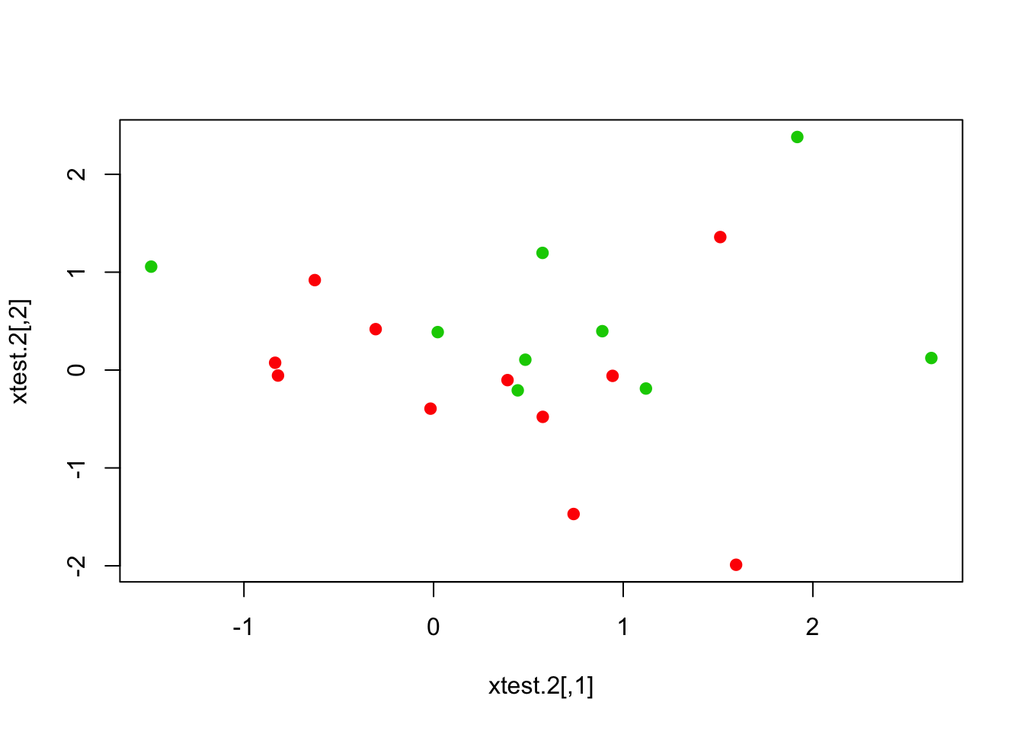

```r
set.seed(1)
xtest.2 = matrix(rnorm(20*2), ncol = 2)
ytest.2 = sample(c(-1,1),20,rep = T)
xtest.2[ytest.2==1,] = xtest[ytest.2==1,] + 0.5
testdat.2 = data.frame(x=xtest.2, y = as.factor(ytest.2))

plot(xtest.2,col = (ytest.2+5)/2,pch = 19)
```

```r
ypred.3 <- predict(svmfit.3,testdat.2)
caret::confusionMatrix(ypred.3,testdat.2$y)
```

```
## Confusion Matrix and Statistics
##
##           Reference
## Prediction -1  1
##         -1 10  6
##         1   1  3
##
##                Accuracy : 0.65
##                  95% CI : (0.4078, 0.8461)
##     No Information Rate : 0.55
##     P-Value [Acc > NIR] : 0.2520
##
##                   Kappa : 0.2553
##  Mcnemar's Test P-Value : 0.1306
##
##             Sensitivity : 0.9091
##             Specificity : 0.3333
##          Pos Pred Value : 0.6250
##          Neg Pred Value : 0.7500
##              Prevalence : 0.5500
##          Detection Rate : 0.5000
##    Detection Prevalence : 0.8000
##       Balanced Accuracy : 0.6212
##
##        'Positive' Class : -1
##
```

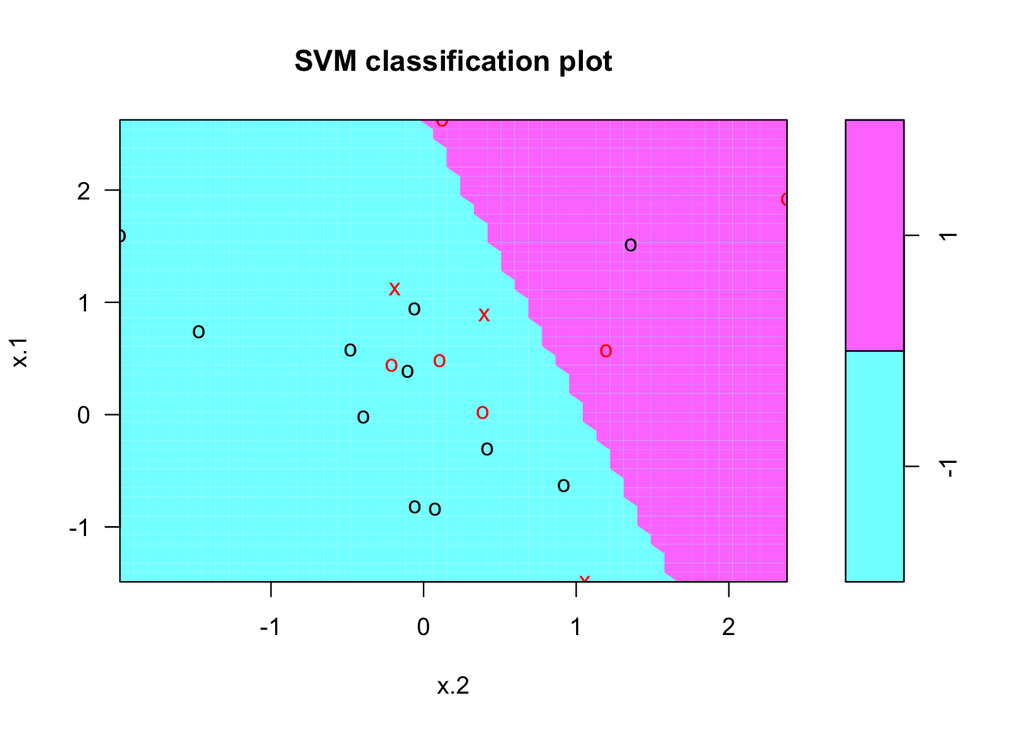

```r
plot(svmfit.3,testdat.2)
```

## How about using a cost of 1?

Does it perform better than the previous model on the test data

```r
svmfit.4 <- svm(y~.,data = dat2, kernel = "linear", cost = 1)
summary(svmfit.4)
```

```
##
## Call:
## svm(formula = y ~ ., data = dat2, kernel = "linear", cost = 1)
##
##
## Parameters:
##    SVM-Type:  C-classification
##  SVM-Kernel:  linear
##        cost:  1
##       gamma:  0.5
##
## Number of Support Vectors:  7
##
##  ( 4 3 )
##
##
## Number of Classes:  2
##
## Levels:
##  -1 1
```

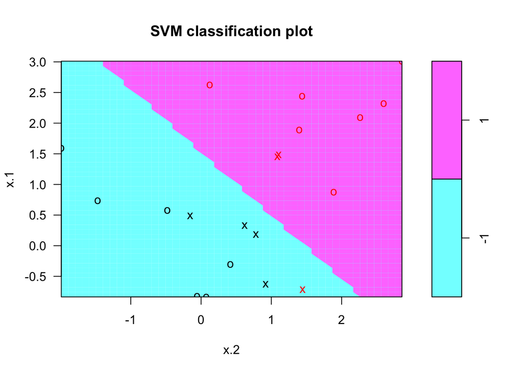

```r
plot(svmfit.4,dat2)
```

```r
caret::confusionMatrix(predict(svmfit.4,dat2),dat2$y)
```

```
## Confusion Matrix and Statistics
##
##           Reference
## Prediction -1  1
##         -1 10  1
##         1   0  9
##
##                Accuracy : 0.95
##                  95% CI : (0.7513, 0.9987)
##     No Information Rate : 0.5
##     P-Value [Acc > NIR] : 2.003e-05
##
##                   Kappa : 0.9
##  Mcnemar's Test P-Value : 1
##
##             Sensitivity : 1.0000
##             Specificity : 0.9000
##          Pos Pred Value : 0.9091
##          Neg Pred Value : 1.0000
##              Prevalence : 0.5000
##          Detection Rate : 0.5000
##    Detection Prevalence : 0.5500
##       Balanced Accuracy : 0.9500
##
##        'Positive' Class : -1
##
```

```r
ypred.4 <- predict(svmfit.4,testdat.2)
caret::confusionMatrix(ypred.4,testdat.2$y)
```

```
## Confusion Matrix and Statistics
##
##           Reference
## Prediction -1  1
##         -1 10  6
##         1   1  3
##
##                Accuracy : 0.65
##                  95% CI : (0.4078, 0.8461)
##     No Information Rate : 0.55
##     P-Value [Acc > NIR] : 0.2520
##
##                   Kappa : 0.2553
##  Mcnemar's Test P-Value : 0.1306
##
##             Sensitivity : 0.9091
##             Specificity : 0.3333
##          Pos Pred Value : 0.6250
##          Neg Pred Value : 0.7500
##              Prevalence : 0.5500
##          Detection Rate : 0.5000
##    Detection Prevalence : 0.8000
##       Balanced Accuracy : 0.6212
##
##        'Positive' Class : -1
##
```

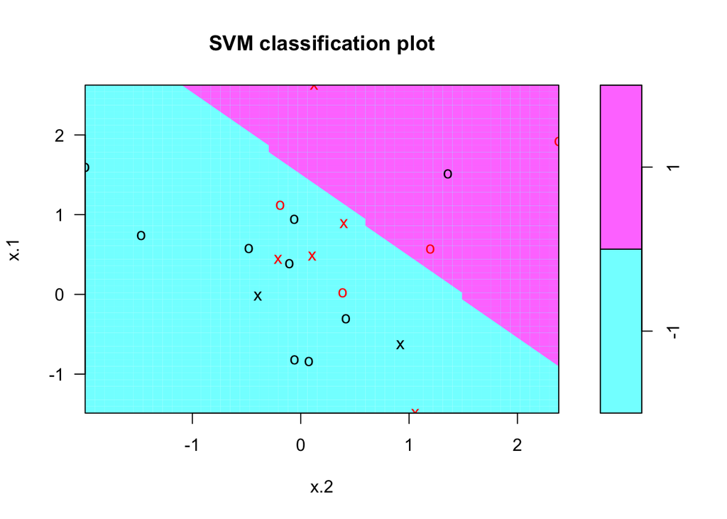

```r
plot(svmfit.4,testdat.2)
```

# 9.6.2 Support Vectoe Machines

We use the same function as before - svm(), but would use kernel = ‘polyinomial’ along with degree argument. For radial kernel, we use kernel = ‘radial’ with specification for gamma

Lets generate some data with non linear class boundary

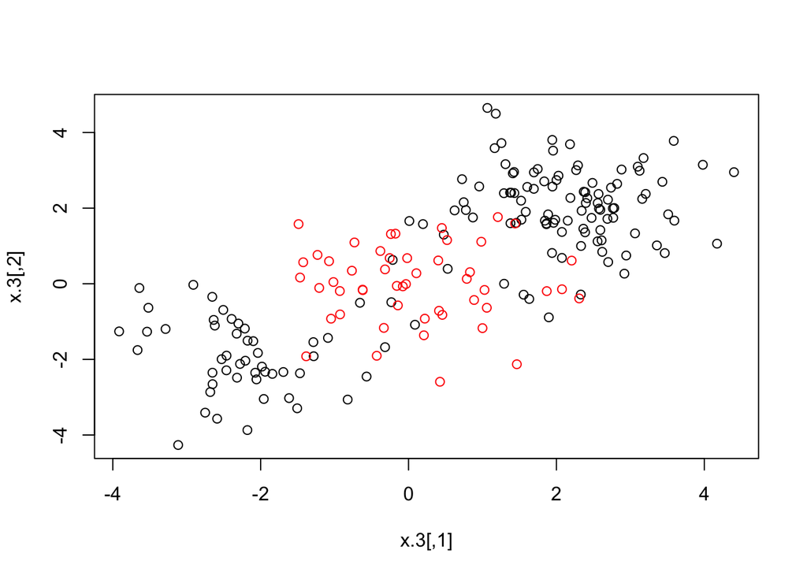

```r
set.seed(1)
x.3 = matrix(rnorm(200*2), ncol = 2)
x.3[1:100,] = x.3[1:100,] + 2
x.3[101:150,] = x.3[101:150,] - 2
y.3 = c(rep(1,150), rep(2,50))
dat3 = data.frame(x = x.3, y = as.factor(y.3))

plot(x.3,col = y.3)
```

## Split the data into training and test samples

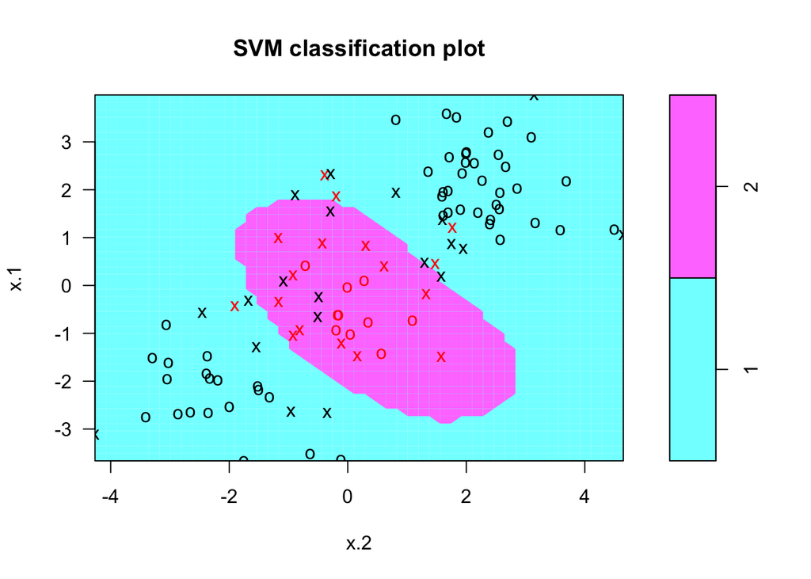

```r
train = sample(200,100)
svm.mach <- svm(y~., data = dat3[train,], kernel = 'radial', cost = 1, gamma = 1)
plot(svm.mach, dat3[train,])
```

```r
summary(svm.mach)
```

```
##
## Call:
## svm(formula = y ~ ., data = dat3[train, ], kernel = "radial",
##     cost = 1, gamma = 1)
##
##
## Parameters:
##    SVM-Type:  C-classification
##  SVM-Kernel:  radial
##        cost:  1
##       gamma:  1
##
## Number of Support Vectors:  37
##
##  ( 17 20 )
##
##
## Number of Classes:  2
##
## Levels:
##  1 2
```

What if we increased the cost

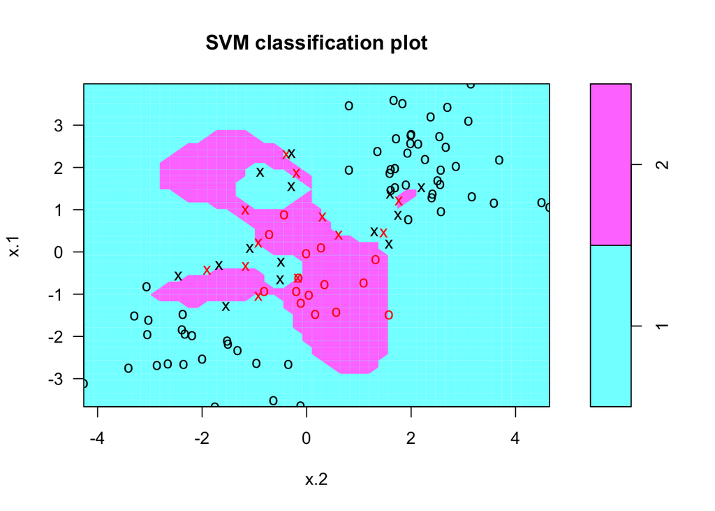

```r
svm.mach.1 <- svm(y~., data = dat3[train,], kernel = 'radial', cost = 1e5, gamma = 1)
plot(svm.mach.1, dat3[train,])
```

```r
set.seed(1)
tune.out.1 <- tune(svm,y~.,data = dat3[train,],kernel = "radial", ranges = list(cost = c(0.1,1,10,100,1000),gamma = c(0.5,1,2,3,4)))
summary(tune.out.1)
```

```
##
## Parameter tuning of 'svm':
##
## - sampling method: 10-fold cross validation
##
## - best parameters:
##  cost gamma
##     1     2
##
## - best performance: 0.12
##
## - Detailed performance results:
##     cost gamma error dispersion
## 1  1e-01   0.5  0.27 0.11595018
## 2  1e+00   0.5  0.13 0.08232726
## 3  1e+01   0.5  0.15 0.07071068
## 4  1e+02   0.5  0.17 0.08232726
## 5  1e+03   0.5  0.21 0.09944289
## 6  1e-01   1.0  0.25 0.13540064
## 7  1e+00   1.0  0.13 0.08232726
## 8  1e+01   1.0  0.16 0.06992059
## 9  1e+02   1.0  0.20 0.09428090
## 10 1e+03   1.0  0.20 0.08164966
## 11 1e-01   2.0  0.25 0.12692955
## 12 1e+00   2.0  0.12 0.09189366
## 13 1e+01   2.0  0.17 0.09486833
## 14 1e+02   2.0  0.19 0.09944289
## 15 1e+03   2.0  0.20 0.09428090
## 16 1e-01   3.0  0.27 0.11595018
## 17 1e+00   3.0  0.13 0.09486833
## 18 1e+01   3.0  0.18 0.10327956
## 19 1e+02   3.0  0.21 0.08755950
## 20 1e+03   3.0  0.22 0.10327956
## 21 1e-01   4.0  0.27 0.11595018
## 22 1e+00   4.0  0.15 0.10801234
## 23 1e+01   4.0  0.18 0.11352924
## 24 1e+02   4.0  0.21 0.08755950
## 25 1e+03   4.0  0.24 0.10749677
```

```r
ypred.5 <- predict(tune.out.1$best.model, newdata = dat3[-train,])
caret::confusionMatrix(ypred.5,dat3$y[-train])
```

```
## Confusion Matrix and Statistics
##
##           Reference
## Prediction  1  2
##          1 74  7
##          2  3 16
##
##                Accuracy : 0.9
##                  95% CI : (0.8238, 0.951)
##     No Information Rate : 0.77
##     P-Value [Acc > NIR] : 0.0006692
##
##                   Kappa : 0.6993
##  Mcnemar's Test P-Value : 0.3427817
##
##             Sensitivity : 0.9610
##             Specificity : 0.6957
##          Pos Pred Value : 0.9136
##          Neg Pred Value : 0.8421
##              Prevalence : 0.7700
##          Detection Rate : 0.7400
##    Detection Prevalence : 0.8100
##       Balanced Accuracy : 0.8283
##
##        'Positive' Class : 1
##
```

# ROC Curves

We’ll use both pROC and ROCR packages in the this lab. In order to plot the ROCs we need the fitted values of the SVM and not the class labels. As it was done in logsitic regression where the probabilities were used for ROC and not the class label.

How do we get the fitted values from the SVM model? We set the argument “decision.values = TRUE”. Let’s try that.

```r
library(pROC)
```

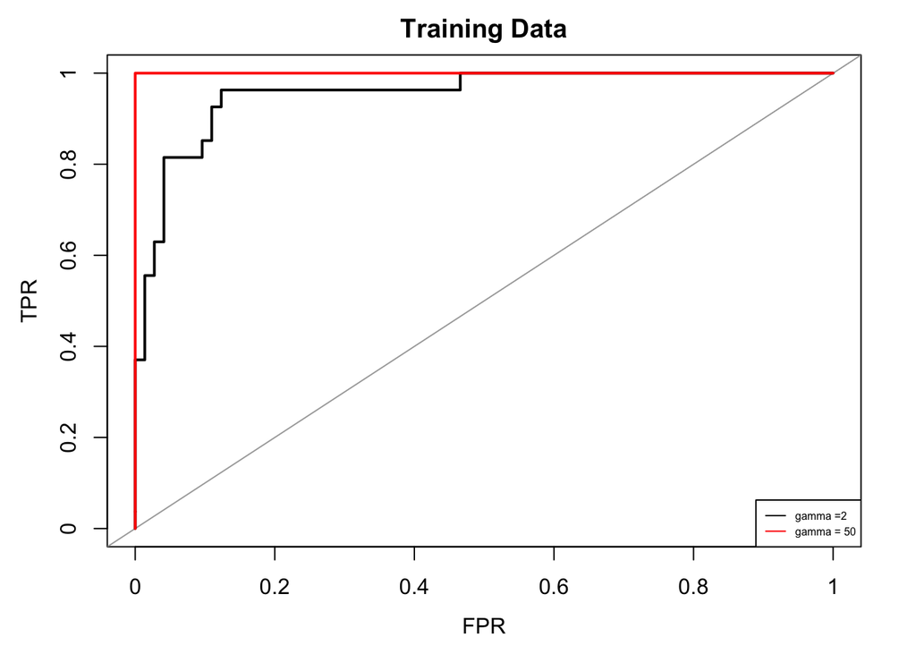

```r
svm.mach.opt <- svm(y~., data = dat3[train,], kernel = 'radial', cost = 1, gamma = 2,decision.values = T)
fittedVals <- attributes(predict(svm.mach.opt,dat3[train,], decision.values = T))$decision.values
roc.curve.train <- pROC::roc(response = dat3[train,'y'], predictor = fittedVals)
plot(roc.curve.train,asp = NA, legacy.axes = T,xlab = "FPR", ylab = "TPR", main = "Training Data")

library(ROCR)
rocplot <- function(pred,truth,...){
  predobs <- prediction(pred,truth)
  perf <- performance(predobs, "tpr", "fpr")
  plot(perf,...)
}
#rocplot(fittedVals,dat3[train,'y'], main = "Training Data")

svmfit.flex <- svm(y~., data = dat3[train,], kernel = 'radial', cost = 1, gamma = 50,decision.values = T)
fitted.flex <- attributes(predict(svmfit.flex,dat3[train,], decision.values = T))$decision.values
roc.flex <- pROC::roc(response = dat3[train,'y'], predictor = fitted.flex)
plot(roc.flex, asp = NA, legacy.axes = T,add = T, col = 'red')
legend("bottomright", legend = c("gamma =2", "gamma = 50"), col = c("black", "red"), lty = c(1,1),cex = 0.5)
```

### Ok great, what would be the performance on the test set?

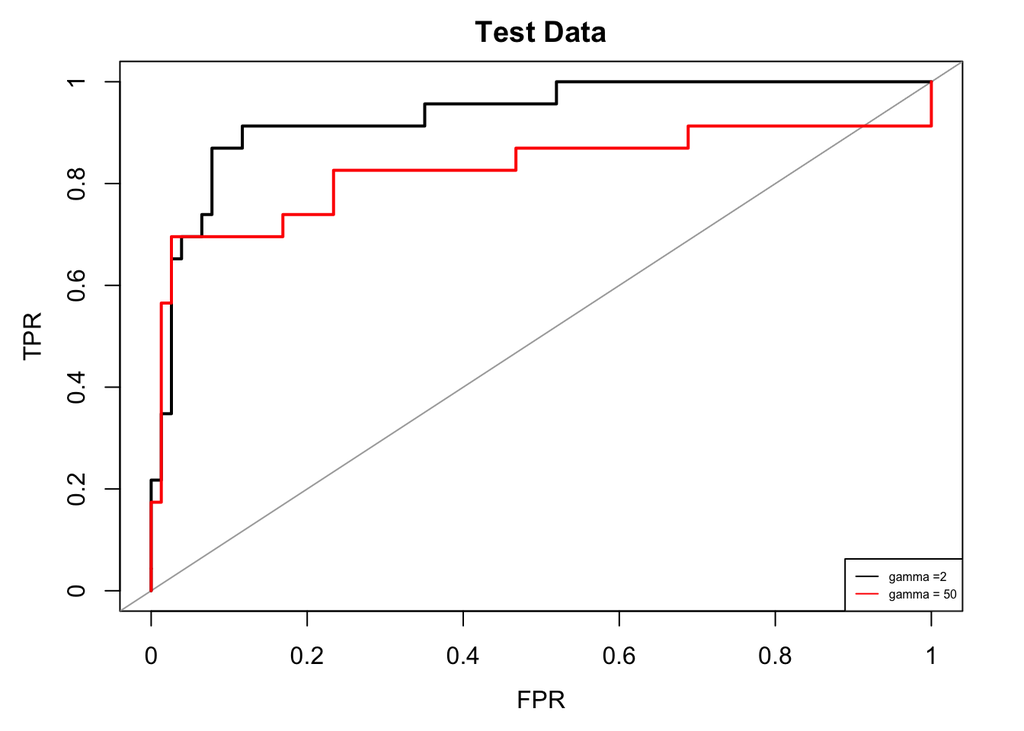

```r
fittedVals.test <- attributes(predict(svm.mach.opt,dat3[-train,], decision.values = T))$decision.values
fitted.flex.test <- attributes(predict(svmfit.flex,dat3[-train,], decision.values = T))$decision.values
roc.curve.test <- pROC::roc(response = dat3[-train,'y'], predictor = fittedVals.test)
plot(roc.curve.test,asp = NA, legacy.axes = T,xlab = "FPR", ylab = "TPR", main = "Test Data")
roc.flex.test <- pROC::roc(response = dat3[-train,'y'], predictor = fitted.flex.test)
plot(roc.flex.test, asp = NA, legacy.axes = T,add = T, col = 'red')
legend("bottomright", legend = c("gamma =2", "gamma = 50"), col = c("black", "red"), lty = c(1,1),cex = 0.5)
```

# 9.6.4 SVM Multiclass problem

Lets create another class and it to the data that we have already created

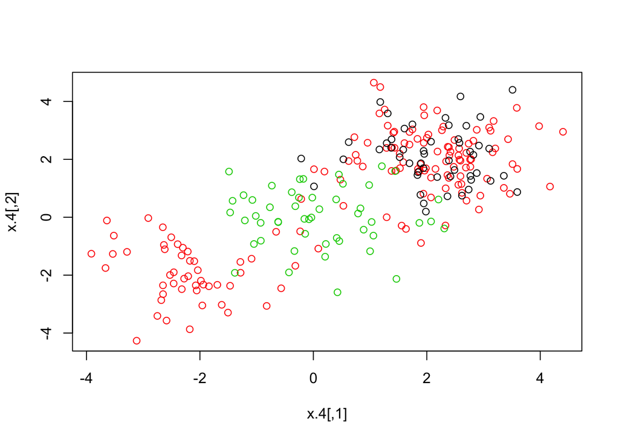

```r
set.seed(1)
x.4 <- rbind(x.3,matrix(rnorm(50*2),ncol = 2))
y.4 <- c(y.3,rep(0,50))
x.4[y.4==0,] = x.4[y.4==0,] + 2
dat4 <- data.frame(x = x.4,y = as.factor(y.4))
plot(x.4,col = (y.4 + 1))
```

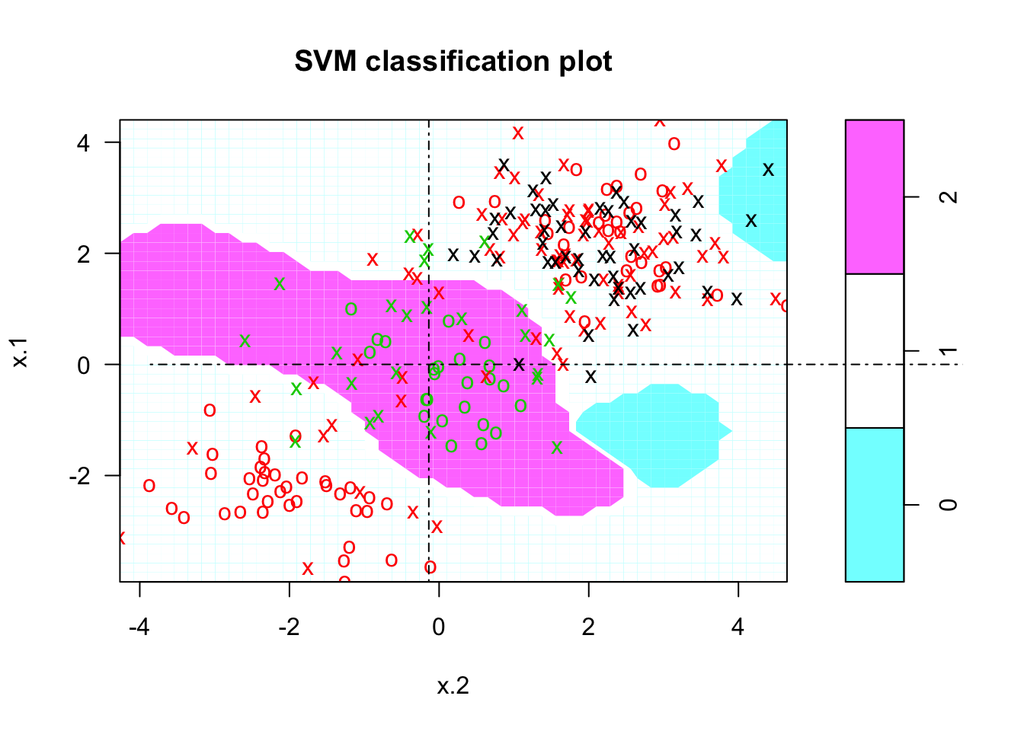

```r
svmfit.multiclass <- svm(y~., data = dat4, kernel = "radial", cost = 10, gamma = 1)
plot(svmfit.multiclass,dat4)
abline(h=0,lty=4)
abline(v=-1.3,lty = 4)
```

# 9.6.5 Application to the Gene Expression Data

```r
library(ISLR)
names(Khan)
```

```
## [1] "xtrain" "xtest"  "ytrain" "ytest"
```

```r
dim(Khan$xtrain)
```

```
## [1]   63 2308
```

```r
hmm <- Khan$xtrain
table(Khan$ytrain)
```

```
##
##  1  2  3  4
##  8 23 12 20
```

```r
table(Khan$ytest)
```

```
##
## 1 2 3 4
## 3 6 6 5
```

```r
dat5 <- data.frame(x = Khan$xtrain, y = as.factor(Khan$ytrain))
out <- svm(y~., data = dat5, kernel = "linear",cost = 10)
summary(out)
```

```
##
## Call:
## svm(formula = y ~ ., data = dat5, kernel = "linear", cost = 10)
##
##
## Parameters:
##    SVM-Type:  C-classification
##  SVM-Kernel:  linear
##        cost:  10
##       gamma:  0.0004332756
##
## Number of Support Vectors:  58
##
##  ( 20 20 11 7 )
##
##
## Number of Classes:  4
##
## Levels:
##  1 2 3 4
```

```r
caret::confusionMatrix(out$fitted,dat5$y)
```

```
## Confusion Matrix and Statistics
##
##           Reference
## Prediction  1  2  3  4
##          1  8  0  0  0
##          2  0 23  0  0
##          3  0  0 12  0
##          4  0  0  0 20
##
## Overall Statistics
##
##                Accuracy : 1
##                  95% CI : (0.9431, 1)
##     No Information Rate : 0.3651
##     P-Value [Acc > NIR] : < 2.2e-16
##
##                   Kappa : 1
##  Mcnemar's Test P-Value : NA
##
## Statistics by Class:
##
##                      Class: 1 Class: 2 Class: 3 Class: 4
## Sensitivity             1.000   1.0000   1.0000   1.0000
## Specificity             1.000   1.0000   1.0000   1.0000
## Pos Pred Value          1.000   1.0000   1.0000   1.0000
## Neg Pred Value          1.000   1.0000   1.0000   1.0000
## Prevalence              0.127   0.3651   0.1905   0.3175
## Detection Rate          0.127   0.3651   0.1905   0.3175
## Detection Prevalence    0.127   0.3651   0.1905   0.3175
## Balanced Accuracy       1.000   1.0000   1.0000   1.0000
```

### Super, now whats the performance on the ytest

```r
dat.te = data.frame(x = Khan$xtest, y = as.factor(Khan$ytest))
pred.te = predict(out,newdata = dat.te)
table(pred.te,dat.te$y)
```

```
##
## pred.te 1 2 3 4
##       1 3 0 0 0
##       2 0 6 2 0
##       3 0 0 4 0
##       4 0 0 0 5
```